# Gradients in richness and turnover of a forest passerine's diet prior to breeding: A mixed model approach applied to faecal metabarcoding data - Shutt - 2020 - Molecular Ecology - Wiley Online Library

[Molecular Ecology](https://onlinelibrary.wiley.com/journal/1365294x)

[Volume 29, Issue 6](https://onlinelibrary.wiley.com/toc/1365294x/2020/29/6) p. 1199-1213

ORIGINAL ARTICLE

Full Access

# Gradients in richness and turnover of a forest passerine's diet prior to breeding: A mixed model approach applied to faecal metabarcoding data

[Jack D. Shutt](https://onlinelibrary.wiley.com/action/doSearch?ContribAuthorStored=Shutt%2C+Jack+D)

[James A. Nicholls](https://onlinelibrary.wiley.com/action/doSearch?ContribAuthorStored=Nicholls%2C+James+A)

[Urmi H. Trivedi](https://onlinelibrary.wiley.com/action/doSearch?ContribAuthorStored=Trivedi%2C+Urmi+H)

[Malcolm D. Burgess](https://onlinelibrary.wiley.com/action/doSearch?ContribAuthorStored=Burgess%2C+Malcolm+D)

[Graham N. Stone](https://onlinelibrary.wiley.com/action/doSearch?ContribAuthorStored=Stone%2C+Graham+N)

[Jarrod D. Hadfield](https://onlinelibrary.wiley.com/action/doSearch?ContribAuthorStored=Hadfield%2C+Jarrod+D)

[Albert B. Phillimore](https://onlinelibrary.wiley.com/action/doSearch?ContribAuthorStored=Phillimore%2C+Albert+B)

First published: 26 February 2020

https://doi.org/10.1111/mec.15394

Citations: 3

Jack D. Shutt and James A. Nicholls contributed equally to this work.

## Abstract

Rather little is known about the dietary richness and variation of generalist insectivorous species, including birds, due primarily to difficulties in prey identification. Using faecal metabarcoding, we provide the most comprehensive analysis of a passerine's diet to date, identifying the relative magnitudes of biogeographic, habitat and temporal trends in the richness and turnover in diet of *Cyanistes caeruleus* (blue tit) along a 39 site and 2° latitudinal transect in Scotland. Faecal samples were collected in 2014–2015 from adult birds roosting in nestboxes prior to nest building. DNA was extracted from 793 samples and we amplified COI and 16S minibarcodes. We identified 432 molecular operational taxonomic units that correspond to putative dietary items. Most dietary items were rare, with Lepidoptera being the most abundant and taxon‐rich prey order. Here, we present a statistical approach for estimation of gradients and intersample variation in taxonomic richness and turnover using a generalised linear mixed model. We discuss the merits of this approach over existing tools and present methods for model‐based estimation of repeatability, taxon richness and Jaccard indices. We found that dietary richness increases significantly as spring advances, but changes little with elevation, latitude or local tree composition. In comparison, dietary composition exhibits significant turnover along temporal and spatial gradients and among sites. Our study shows the promise of faecal metabarcoding for inferring the macroecology of food webs, but we also highlight the challenge posed by contamination and make recommendations of laboratory and statistical practices to minimise its impact on inference.

## 1 INTRODUCTION

Insectivorous passerine birds in temperate environments tend to be dietary generalists feeding on a broad range of invertebrate taxa (Betts, 1955; Cholewa & Wesołowski, 2011). There is potential for the diet of such generalists to vary over geographic gradients, among habitats and seasonally within a year. Such dietary variability within generalist species is poorly understood and could have profound ecological consequences. Spatial variation in resource availability has implications for geographic patterns in population density, breeding productivity and the degree to which local adaptation in resource use may evolve. Seasonal variation in resource consumption has implications for the optimal scheduling of life history events, such as reproduction (Charmantier et al., 2008; Durant et al., 2005) and seasonal movements (Thorup et al., 2017).

Spatiotemporal trends in diet will arise from a combination of underlying trends in invertebrate resource availability and the prey preferences of the consumer. Species richness—or α‐diversity—of temperate invertebrate taxa generally decreases with increasing latitude (Baselga, 2008) and peaks at mid‐elevations (Beck et al., 2017) and in the summer months (Thomsen et al., 2016). Within forests, invertebrate richness can vary among tree taxa by more than an order of magnitude, and in the UK has been found to be highest on *Salix*, *Quercus* and *Betula* (Kennedy & Southwood, 1984; Shutt, Burgess, & Phillimore, 2019). In addition to changes in species richness, species composition may change from one community to the next, which is quantified as β‐diversity (Baselga, 2010; Whittaker, 1972). While there is evidence that forest invertebrate communities show turnover over biogeographic gradients (Novotny & Weiblen, 2005) and among host tree taxa (Murakami, Ichie, & Hirao, 2008), the relative magnitude of turnover along different gradients has received scant attention (Novotny & Weiblen, 2005). Whether diet mirrors these gradients in resource availability will largely depend on how much prey selection by the consumer departs from random.

Forest‐dwelling hole‐nesting insectivorous birds, such as blue tits (*Cyanistes caeruleus*), have been subject to decades of intensive study (Perrins, 1979). While the diet of nestlings has proven relatively straightforward to quantify, either via videos/cameras at the nest (Samplonius, Kappers, Brands, & Both, 2016), or neck collars on nestlings (Burger et al., 2012), much less is known about the diet of adults (but see Cholewa & Wesołowski, 2011; Gibb, 1954). The paucity of information about adult diet arises because these birds often forage high in trees on small prey items. To date most of our taxonomic information on adult tit diet has been derived from dissections of the gizzard and gut contents of euthanised birds (Betts, 1955), a method that precludes the identification of soft‐bodied dietary items, has relatively poor taxonomic resolution (e.g., order or family level) and is destructive. These studies reveal that tits consume various insects (including Lepidoptera, Hemiptera, Diptera, Coleoptera, Hymenoptera) and spiders, as well as some plant matter in winter (Betts, 1955; Cholewa & Wesołowski, 2011; Cramp & Perrins, 1993).

The advent of next‐generation sequencing and faecal DNA metabarcoding now provides a nondestructive means of obtaining diet information at a fine taxonomic resolution (Pompanon et al., 2012; Symondson, 2002; Taberlet, Coissac, Pompanon, Brochmann, & Willerslev, 2012). Where invertebrates comprise a large proportion of the diet, DNA barcodes from the rapidly evolving cytochrome oxidase I (COI) mitochondrial gene have become the standard and allow identification to species‐level in many cases (Kress, García‐Robledo, Uriarte, & Erickson, 2015). To date, most published faecal metabarcoding studies have examined variation in mammalian diet (Bohmann et al., 2011; Clare, Symondson, Broders, et al., 2014; Clare, Symondson, & Fenton, 2014; Razgour et al., 2011). In comparison to mammals in general, and bats in particular, application of faecal metabarcoding for inference of the diet of avian insectivores is a small but rapidly growing field. Progress has been hampered by the challenge of extracting and successfully amplifying dietary DNA from avian faeces (Jedlicka, Sharma, & Almeida, 2013; Vo & Jedlicka, 2014). As such, avian faecal metabarcoding studies have sampled small numbers of individuals and/or locations (Table 1) and the latter limitation has precluded detailed analysis of the drivers of spatial or temporal variation in the diet of avian insectivores (for an exception see Sullins et al., 2018).

Table 1. Sampling and laboratory protocols employed by published faecal barcoding studies focusing on the invertebrate component of avian diet. An entry of “None” means that while steps may have been taken in the study, no specific method was detailed

| Number of study species (most common species) | Total number of samples (maximum number of samples per species) | Number of sites (region) | Controls | Measures taken to assess repeatability | Reference |
| --- | --- | --- | --- | --- | --- |
| 1 (Lesser Prairie‐Chicken) | 314 | 4 (Kansas and Colorado, USA) | None | None | Sullins et al. (2018) |
| 1 (Western Bluebird) | 210 | 3 (neighbouring vineyards, California, USA) | None | 10 faeces subsampled | Jedlicka et al. (2016) |
| 3 (Wood Thrush) | 137 (51) | 1 (Pennsylvania, USA) | PCR negatives and positives | None | Trevelline, Nuttle, Hoenig, et al. (2018) |
| 1 (Louisiana Waterthrush) | 130 | 2 (Arkansas and Pennsylvania, USA) | None | None | Trevelline, Latta, Marshall, Nuttle, and Porter (2016) |
| 1 (Louisiana Waterthrush) | 92 | 3 (headwater streams, Pennsylvania, USA) | None | None | Trevelline, Nuttle, Porter, et al. (2018) |
| 1 (Rufous hummingbird) | 30 | 1 (Vancouver Island, Canada) | 1 x extraction negative | None | Moran, Prosser, and Moran (2019) |
| 13 (Lewin's Honeyeater) | 82 (29) | 1 (Bundaberg, Australia) | Extraction negatives | PCR run twice to test amplification repeatability | Crisol‐Martínez, Moreno‐Moyano, Wormington, Brown, and Stanley (2016) |
| 1 (Western Bluebird)* | 16 | 2 (neighbouring vineyards, California, USA) | None | Faecal sample was subdivided and run on two extraction kits | Jedlicka et al. (2013) |
| 4 (Blue tit, Great Tit, Willow Tit) | 14 (4) | 2 (Oulu and Kuusamo, Finland) | Extraction negative | None | Rytkönen et al. (2019) |
| 3 (Sedge Warbler)<sup>a</sup> | 11 (6) | 3 (South Wales, UK) | None | None | King, Symondson, and Thomas (2015) |

- <sup>a</sup> Study employed Sanger sequencing rather than metabarcoding.

To date, the statistical tools employed by the nascent metabarcoding field have been largely borrowed from community ecology. In some studies the objective has been to describe the diet composition of a taxon such that statistical analysis may be unnecessary (De Barba et al., 2014). Metabarcoding studies that focus on patterns in taxon richness commonly apply a two‐step analysis, first using rarefaction to quantify diversity at a focal sampling level and then using a statistical model to examine variation in taxon richness among samples (Quéméré et al., 2013). Studies interested in how taxonomic composition varies among samples have tended to rely on pairwise metrics, such as the Jaccard index, and nonparametric methods, such as PERMANOVA and the Mantel test (Alberdi, Aizpurua, Gilbert, & Bohmann, 2018; Mata et al., 2019; Trevelline, Nuttle, Hoenig, et al., 2018). Generalised linear mixed models (GLMMs) and their extensions provide a method for including structure in the data collection and multiple predictors into an analysis (Warton et al., 2015), but few studies have utilised them in diet metabarcoding to date (for exceptions see Mata et al., 2019; Nichols, Åkesson, & Kjellander, 2016).

Here, we employ faecal metabarcoding using COI minibarcodes to infer the diet of an insectivorous woodland passerine, the blue tit, in early spring along a 220 km transect in Scotland (Figure S1 in Appendix S1). We have three main aims: (a) to quantify dietary taxon richness and composition at the molecular operational taxonomic unit (MOTU) level; (b) to quantify the magnitude of changes in both measures along gradients of time (day of year), latitude, elevation and tree taxon composition; and (c) to quantify gradients in the contributions that six key invertebrate orders (Araneae, Coleoptera, Diptera, Hemiptera, Hymenoptera, Lepidoptera) make to diet. We show that by applying a GLMM to presence/absence data it is possible to estimate changes in taxon richness and turnover among points and along gradients. We also demonstrate how this mixed model approach can be used to estimate repeatability and control for some types of systematic contamination.

## 2 MATERIALS AND METHODS

### 2.1 Field data collection

Fieldwork was conducted during the springs of 2014 and 2015 at 39 predominantly deciduous woodland sites that together comprise a 220 km latitudinal transect in Scotland (Shutt, Bolton, Benedicto Cabello, Burgess, & Phillimore, 2018). At each site there were six Schwegler 1B 26 mm hole nestboxes distributed at approximately 40 m intervals. From mid‐March the base of each nestbox was lined with greaseproof paper—with the aim of slowing DNA degradation (Oehm, Juen, Nagiller, Neuhauser, & Traugott, 2011)—which was replaced when damaged or heavily soiled, and removed at the onset of nest building or once a bird had attempted removal. Each nestbox was inspected on alternate days and faeces on the greaseproof paper were removed with sterilised tweezers (after use they were wiped with laboratory tissue and flamed), with up to a maximum of three faeces collected in a 2 ml Eppendorf tube containing pure ethanol. The total number of faeces in a nestbox was recorded (excluding 129 samples from early 2014). Samples were stored at −18°C within a day of collection and transferred to a −20°C freezer at the end of each spring. Faecal samples were collected from 35 of the 39 sites from 19 March in 2014 and 18 March in 2015 until nest building, giving a median sampling range of 20 days per site in 2014 and 24 days in 2015 (Table S1 in Appendix S1).

Latitude (site range 55.98–57.88°N) and elevation (10–433 m) were obtained for each nestbox (Shutt et al., 2018). Site‐level habitat metrics were derived from surveys of numbers of trees of different genera belonging to three size classes (based on girth at breast height) within 15 m radius of each nestbox, as described in Shutt et al. (2018). The site‐level habitat variables we considered were total foliage, tree diversity (Simpson's index), the amount of oak foliage and the amount of birch foliage (Shutt et al., 2018).

### 2.2 Molecular protocol

We balanced sampling across nestboxes and dates as far as possible by imposing an upper limit of 10 samples per nestbox per year and where this maximum was exceeded we subsampled such that we maximised the range of dates per nestbox. If multiple faeces (*n* = 2–3) were present within a sample tube, part of each individual scat was used for the DNA extraction with the aim of sampling a broader range of diet. This protocol resulted in processing of 793 of a total of 959 faecal samples.

Thirty samples were processed in duplicate to allow us to estimate technical repeatability. The selected samples were evenly distributed throughout the sampling period, including samples from multiple sampling locations in both 2014 and 2015. The faeces for each of the 30 duplicated samples were evenly divided into two and DNA extractions were performed on each subsample; although each subsample contained sections from along the entire length of the original faeces, the faeces was not completely homogenised before subsampling. Each duplicate extraction was subsequently treated as an independent sample for all downstream processes. All aspects of the laboratory protocol (DNA extraction, PCR amplifications, PCR clean‐up, sequencing on a MiSeq run) were performed at different times using different aliquots of reagents for each replicate within a pair of subsamples. In addition we included 24 controls (including extraction negatives, PCR negatives and *Dryocosmus israeli* as a non‐native invertebrate PCR positive).

DNA was extracted from faecal samples using the QIAamp DNA Stool Mini kit, following the protocol for pathogen detection with a few custom modifications designed to improve DNA yields (see online protocol for details; https://doi.org/10.17504/protocols.io.ve6e3he). Three loci were targeted for amplification through PCR—the standard animal barcoding gene (COI), a secondary barcoding gene to detect invertebrate prey DNA and confirm the faecal sample originated from a blue tit and no other hole‐roosting or ‐nesting passerine (16S rRNA), and a standard plant barcoding gene (rbcL; see online protocol for further details; https://doi.org/10.17504/protocols.io.2jdgci6). Given that DNA from dietary items is expected to be very degraded, the primers used amplified a small “minibarcode” region of each gene (184–220 base pairs). Invertebrate primer sets were validated to ensure that they would amplify DNA from the expected range of invertebrate taxa (two orders of arachnids, isopods, nine insect orders).

We followed a two‐stage PCR process, firstly to amplify the target regions, then secondly to add indexed Illumina adaptors to the amplicons from each sample. Amplicons were multiplexed into three pools, each containing between 273 and 276 samples (inclusive of 30 replicate samples) and eight controls (3x PCR positives, 3x PCR negatives and 2x extraction negatives; a total of 24 controls across the whole experiment). Each pool was sequenced on an Illumina MiSeq, using 150 bp paired‐end reads.

### 2.3 Bioinformatics processing

Sequencing reads were initially demultiplexed into sets corresponding to individual faecal samples using the index combinations present within the adaptor sequences using bcl2fastq (version v2.17.1.14). Reads were then demultiplexed using fastq‐multx from ea‐utils (version 1.1.2‐537) with parameter ‘‐m 2’ into sets corresponding to each locus using the locus‐specific primer sequences present at the beginning of each read. Adaptor sequences, primer sequences and poor quality base calls were then removed using cutadapt (version 1.8.3) with parameters: ‘‐m 50’, ‘‐q 30’, ‘‐f fastq’, leaving only sequence corresponding to the targeted gene regions. Subsequent processing of the sequences applied the UPARSE pipeline (initially developed for 16S metabarcoding of bacteria: Edgar, 2013) to data for each locus separately.

The first step in the bioinformatics pipeline was to merge the paired reads derived from either end of the sequenced fragment. This process was successful for all COI and rbcL reads and many 16S reads; 16S reads derived from avian DNA did not overlap, but comparison with known blue tit 16S sequences indicated that these reads could be combined by adding four “N”s between the forward and reverse reads to produce a composite sequence of the correct length (hereafter referred to as fused reads). Reads were then filtered to ensure that within a locus they were all of the same length; this process removed possible pseudogenes incorporating insertions/deletions from the coding COI and rbcL data. The rbcL data were not used for subsequent analyses in this study, and 16S data were only used to confirm the faeces were derived from blue tits. The set of filtered COI sequences was then used for two purposes. Firstly, the set of unique sequences present within the full data set derived from all samples was determined, with counts made of their frequencies. Unique sequences represented by only a single read were removed as they most likely represent sequencing errors. The unique sequences were then clustered into molecular operational taxonomic units (MOTUs), grouping sequences together that had an identity of 98% or more. The most frequently occurring sequence within each MOTU was designated as the reference sequence for that MOTU. The second use of the filtered reads involved mapping them back to this reference set of MOTU sequences on a sample by sample basis, allowing a mismatch of up to 2% between filtered reads and a reference sequence, to provide a more accurate assessment of the frequency of each MOTU within each faecal sample. The taxonomic identity of MOTUs was determined using a blast search of the reference set of MOTU sequences against public databases (GenBank and BOLD).

### 2.4 Quality control and MOTU refinement

Our analysis plan from this point on was preregistered (osf.io/xgvm8). Some aspects of our methods deviate from what was outlined in the preregistration (see Table S1 in Appendix S1 for an explanation of the motivation for these departures). We tested whether samples were from blue tits by verifying the presence of blue tit fused 16S sequences. The highest number of blue tit 16S reads from the 24 control samples was 58 and as a precaution all faecal samples that yielded fewer than 100 blue tit 16S reads were excluded from further analyses as they were not conclusively confirmed to be blue tit faeces (*n* = 9). Of the remaining avian faecal samples, blue tit was the commonest of the fused 16S MOTU in all but one sample, but this sample still had sufficient (*n* = 1,465) blue tit reads to confirm its identity. No other avian DNA was present in any sample.

COI reads were checked from control samples to confirm the presence of positive control species and provide a baseline for background contamination. All nine PCR positive control samples contained MOTUs attributable to *Dryocosmus israeli* (range of reads = 7,796–19,115) and no more than 16 reads of any other MOTU identified as belonging to the Metazoan kingdom. Eight out of nine PCR negative controls contained no more than 19 reads of any MOTU. The ninth was highly contaminated and contained 6,798 reads arising from more than 20 MOTUs. Therefore, we checked for contamination along rows or columns within plates by estimating Spearman's correlations in the number of MOTU reads between samples in neighbouring cells in the same PCR column or row. The row containing the contaminated negative sample was found to have a substantially higher mean level of within row correlation (*r* = .37) than other row and column correlations (mean *r* = .04). This was considered to be most likely a systematic contamination event and this row (*n* = 11 focal samples + 1 negative control) was excluded from all analyses. In addition, closer inspection of the contaminated plate revealed two wells (both faecal samples) in the neighbouring row to the contamination event containing very similar MOTUs with the contaminated row and these were also removed from further analysis. Of the six extraction negative controls, four contained no MOTU at a higher read frequency than three. The remaining two contained contamination (maximum reads = 10,037 and 1,611) but on further inspection there was no evidence for this being systematic. As there were few cases where a control (positive or negative) had >20 reads for any nontarget MOTU, we adopted 20 reads as the cutoff for identifying MOTU presence.

The above steps reduced the number of samples from 847 to 824 (772 focal) containing 2,524 MOTUs. All MOTUs with fewer than 20 reads in any single sample were removed as possible false positives (remaining *n* = 1,432 MOTUs). All MOTUs without any BLAST match, or identified as environmental contamination, were removed (remaining *n* = 1,323). Then, a full taxonomy was obtained for each remaining MOTU and taxonomic reduction of the data set began to eliminate nonprey items. Firstly, only MOTUs belonging to the Metazoan kingdom were considered possible prey items (remaining *n* = 1,078). Then, all MOTUs not belonging to the phyla Annelida, Arthropoda and Mollusca were discarded (remaining *n* = 1,005). Finally, all mites in the data set of orders Astigmata (11), Mesostigmata (56), Oribatida (1), Siphonoptera (2) and Trombidiformes (24) were removed, as they were likely to be ectoparasites rather than actively foraged prey (remaining *n* = 911). For the MOTU identification we required that the percentage match was at least 90% (remaining *n* = 785). Taxa identified to an identification match of 90% or more are considered correct to a minimum of order level, and this is the level that is important to the analyses in this study. Several MOTUs identified as “*Arachnida* sp” were removed on finding that these MOTUs were most closely matched to fungi (remaining *n* = 778). All *Dryocosmus* (positive control) and waxworm (*Galleria mellonella*—from a feeding experiment in 2014 that provided 10 waxworms in a plastic cup adjacent to two nestboxes per site) MOTUs were removed (remaining *n* = 757). Then, all remaining MOTUs belonging to the same best‐hit taxon were merged (remaining *n* = 432). Finally, due to the importance of Lepidoptera to tit diet we assessed the biological plausibility of *Lepidoptera* identifications, which was possible due to comprehensive UK occurrence data for this order (Sterling & Parsons, 2012; Waring & Townsend, 2017). Nineteen of 131 Lepidopteran MOTUs assigned species names were reassigned to a British species when this species was within a 1% match of a geographically implausible top hit. We assigned species status to taxa with a 99% or greater identity match with the blast hit and a histogram of identity matches is provided (Figure S1).

### 2.5 Statistical analysis

Analyses focussed on the presence/absence of MOTUs in a sample, as read numbers are not considered a reliable measure of the amount of a MOTU in a sample due to biases in primer binding and amplification (Clare, 2014; Yu et al., 2012). Control samples were excluded from analyses. DNA within a sample was often derived from multiple faeces, and the effect of this on MOTU presence was controlled for by including number of faeces as a four‐level categorical fixed effect (1, 2, 3, unknown).

To examine geographic, habitat and temporal variation in blue tit diet (Shutt, Nicholls, et al., 2019), we included the presence or absence of each MOTU in each sample as the response variable in a Bayesian generalized linear mixed model (GLMM) with a probit error structure (Hadfield, 2010). This analysis excluded the replicate samples (for reasons discussed in Appendix S1). The effects of year and number of faeces in the sample (treated as categorical) and the effects of ordinal date, latitude, elevation, total foliage, birch foliage, oak foliage and tree diversity (treated as continuous) were treated as fixed. These fixed effects quantify trends in dietary richness. After accounting for these trends, variation in richness amongst sites, nest‐boxes, days within year (categorical) and faecal samples were modelled by fitting each term as random. MOTU effects were fitted as random in order to capture differences amongst MOTUs in their overall prevalence. Variation in the prevalence of individual MOTUs amongst sites, nest‐boxes, days within years (categorical) and faecal samples was modelled by interacting each term with MOTU. In the core model we also allowed the prevalence of individual MOTUs to vary with ordinal date, latitude and elevation effects, again by interacting each term with MOTU to form random regressions. The three slope terms were allowed to covary with each other and the main MOTU effect (the intercept). We also include plate by MOTU random interaction term to control for any plate‐wide contamination by particular MOTUs present. To estimate and correct for any tendency for contamination of rows or columns within a plate we ran an additional model with row (within plate) and column (within plate) interacted with MOTU as random terms and this is the main model that we present in the results.

In addition to the core model, we also ran four additional models, each of which allowed the prevalence of individual MOTUs to vary across one of the four habitat variables. The additional random slope terms were allowed to covary with the original three slope terms and the intercept. However, because of the length of time that the core model took to run (three months) we excluded the day within year term and its interaction with MOTU. The importance of these effects are minor relative to other terms in the model (day in year variance = 0.003, day in year:MOTU variance = 0.036, Table S4a) and the interaction in particular contributed a lot to computation time because with 91 days and 432 MOTUS there are nearly 40,000 effects. All models were run for 260,000 iterations, with the first 60,000 removed as burnin and thinning every 100. These models took approximately two months to run on an iMac 10.13.6 with 3.4 Ghz Intel core i7, 16GB RAM and 4 cores.

To examine trends in the presence/absence of prey orders in blue tit diet, the data set was reduced down to presence/absence of the six most common orders (Araneae, Coleoptera, Diptera, Hemiptera, Hymenoptera and Lepidoptera), termed “focal orders,” which together comprise over 91% of all prey taxa identified. A similar GLMM to that described above was then employed, but with focal order and date, latitude, elevation and tree diversity individually and interacted with focal order as fixed effects. Site, nest‐box, day and faecal samples were fitted as random main effects and as random interactions with focal order. These models were run for 195,000 iterations, with the first 45,000 removed as burnin and thinning every 75.

To assess the repeatability of the approach we used a similar analysis to that described above with the presence/absence of each MOTU as a response for the faecal samples for which extraction, PCR and metabarcoding had been replicated (29 samples × 432 MOTUs). Fixed effects were year and the number of faeces in the sample, both as factors, with random terms limited to MOTU, faecal sample ID, faecal sample ID by MOTU interaction, extraction sample ID and residual. This model was run for 13 million generations with the first 3 million removed as burnin and thinning every 5,000.

All numeric predictor variables in all analyses were scaled to have a mean of 0 and a variance of 1 to provide direct comparability of results. We used parameter expanded priors for the variances such that the marginal priors on all variances followed a scaled (1,000) *F*<sub>1,1</sub> distribution. Traces of posteriors were visually inspected to check for convergence and adequate sampling. For the main model, the effective sample sizes (ESS) were a bit low for some variances (<500), but in all cases the ESS were adequate to provide a reliable point estimate (>100) even if in some instances the accuracy of the credible intervals is poor. As a test of model adequacy we conducted posterior predictive simulations to assess whether key features of the data were captured (Figure S3). We opted to use an MCMCglmm approach rather than much faster numerical integration approaches, such as lme4 (Bates, Maechler, & Bolker, 2012) or glmmTMB (Brooks et al., 2017), because posterior predictions revealed that parameter estimates from MCMCglmm provided an accurate description of the data, whereas those from lme4 and glmmTMB were highly inconsistent (Appendix S1). Additional simulations confirmed that parameter estimates from lme4 were highly biased, most likely because with rare‐outcome data the approximations used for integrating over the random effects break down.

In order to get a quantitative understanding of how α and β diversity change across different levels of biological organisation (e.g., nestbox or site) and as a function of continuous biogeographic variables (e.g., elevation or tree diversity) we develop a framework for focussing repeatability metrics at the appropriate biological level (see Appendix S1). The two‐way dichotomy into between‐group and within‐group that forms the basis of standard repeatability calculations (see Nakagawa & Schielzeth, 2010 for a review) can be seen as a special case. The quantities required for these calculations also appear in many indices developed by ecologists to quantify similarity in community structure. Given this, we show how such indices can also be derived directly from a GLMM which has the advantages that credible intervals can easily be computed, incomplete sampling is naturally dealt with (Chao, Chazdon, Colwell, & Shen, 2006) and changes in the indices as a function of differences in a continuous variable (such as latitude) can be handled. The main disadvantage of the approach is that between‐species correlation structures may typically be richer than what a fitted GLMM assumes, such that variation in community structure may be greater than the model allows. However, posterior predictive checking allows model inadequacies to be detected, and richer correlation structures are available, for example through a phylogeny (Hadfield & Nakagawa, 2010) or through factor analysis (Niku, Hui, Taskinen, & Warton, 2019; Warton et al., 2015).

In Appendix S1 we also present methods for using model outputs to generate expectations for the taxon richness of a faecal sample and Jaccard index (often used in studies of β‐diversity) that quantifies the similarity of facecal samples. This allows us to relate model coefficients back to effect sizes that are more often used in community ecology. However, as the Jaccard index captures both turnover and community nestedness (Baselga, 2010), in the results we mainly use repeatability to quantify turnover.

## 3 RESULTS

### 3.1 Read quality

The three MiSeq runs combined generated 34.04 million raw paired‐end reads, of which 9.8 million were classified as COI amplicons after demultiplexing based on the primer sequences. Amplicons for 16S and rbcL were also generated, but our diet analysis focuses only on COI. 8.9 million merged sequences passed all the quality filters. Out of these, 8.7 million sequences were retained after alignment against the reference OTU sequences.

### 3.2 Diet composition

After identifying samples that tested positive for blue tit 16S DNA, excluding nonprey taxa and collapsing similar sequences, we identified 432 prey MOTUs across 772 faecal samples. Of these MOTUs, 57% could be matched to candidate species on the basis of >99% sequence identity and a voucher/reference specimen identified to species level. A further 4% were >99% matched and therefore identifiable to species level, but lacking a reference initially identified to species level. The remainder of MOTUs are not identifiable to species level but are diagnostically distinct dietary items at minimum within the order identified by the best hit (Figure S1, Table S3 in Appendix S1). The mean number of MOTUs per sample was 5.06, with mode = 3, median = 5 and range = 0–20. The MOTU abundance distribution was highly right‐skewed, with 42.4% recorded in only one sample and 74.3% recorded in five or fewer samples (Figure 1a).

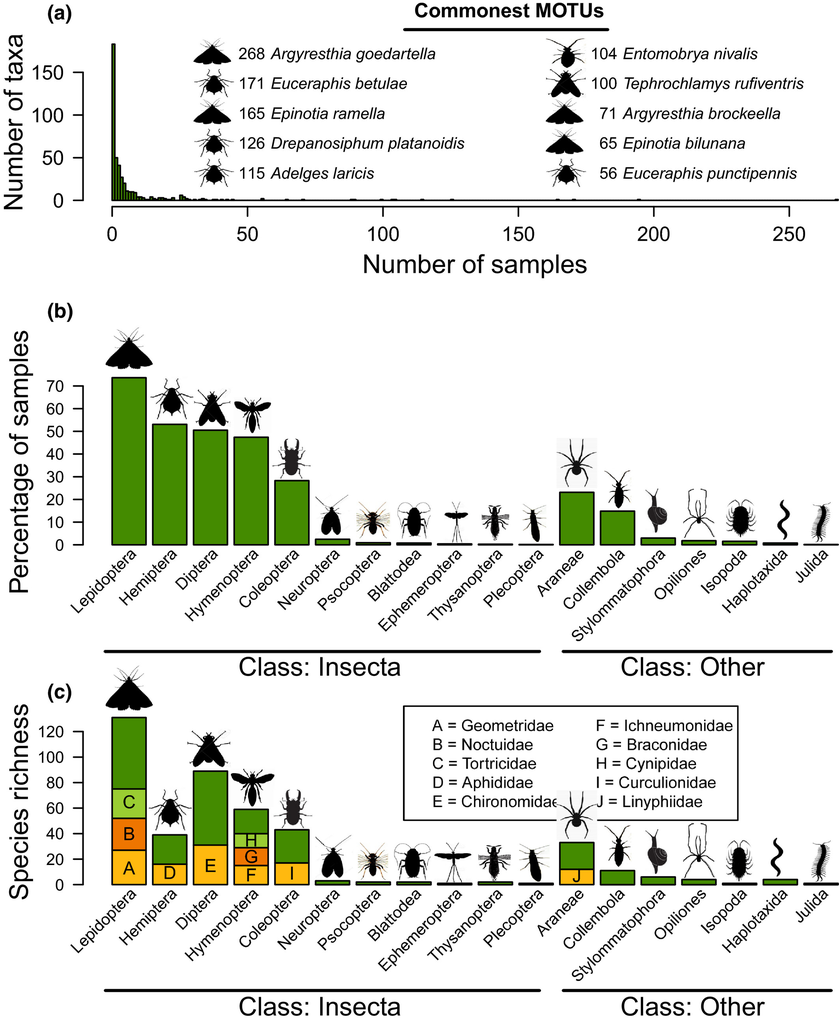

**Figure 1**

(a) Histogram of the abundance distribution of prey MOTUs. Inset details the most prevalent MOTUs identified to species level (those recorded in more than 50 samples), with the number of samples they were recorded in. (b) Relative abundance of prey orders in the spring diet of blue tits. (c) Number of MOTUs within prey orders (families comprising >10 MOTUs are highlighted individually within their respective orders). In (b) and (c) orders within Insecta (left) are split from orders within other classes (right). Images are used to indicate taxonomic order rather than the life‐stage or species that is preyed upon

Eighteen invertebrate orders were encountered in at least one sample, with Insecta contributing 86.1% of MOTUs. Within insects, MOTUs matched to the order Lepidoptera were the most commonly recorded (present in 73.6% of samples, Figure 1b) and taxon‐rich (131 taxa, Figure 1c). Other commonly recorded orders were Hemiptera, Diptera, Hymenoptera, Coleoptera, Araneae and Collembola.

### 3.3 Technical repeatability

The value of faecal metabarcoding as a tool to infer diet depends on how reliable it proves to be and a key measure of this is repeatability. Our protocol included 30 paired replicate extractions from a different portion of the same faecal sample (although note that the sample was not homogenised prior to extraction), 29 of which remained after quality control and which we used to estimate technical repeatability (Table S5g in Appendix S1). The repeatability estimate is highly sensitive to the quantity being measured (measurand), the definition of within and between group, the reference population and whether it is considered on the latent or data scale (Appendix S1). The technical repeatability of a MOTU within a faeces (with only faeces and faeces: MOTU contributing to the between‐group variance) had a posterior mode of 0.305 (95% credible interval = 0.223–0.408) on the data (0,1) scale and 0.783 (0.712–0.845) on the latent (threshold) scale. Variation in MOTU richness at the sample level was reasonable (0.325 [0.118–0.770]) but the richness of samples within faeces are not strongly correlated and so the technical repeatability of richness for a faeces is low (Data; 0.003 [0–0.714], Latent; 0.003 [0–0.676]). However, the credible intervals are large, and the main analysis (see below) shows nonzero correlations between the richness of faeces from the same nestbox suggesting the true technical repeatability of richness must be nonzero.

### 3.4 Dietary MOTU richness

We used a generalized linear mixed model (GLMM) with a binary (threshold) response to examine the predictors of MOTU presence. From the main effects we can gain insights into how dietary MOTU richness (related to α‐diversity) varies across time and space. Day of year predicted a small but significant increase in dietary richness over the course of the spring (b = 0.082 [0.024–0.135], Figure 2c), with the expected number of MOTUs per faecal sample increasing from 1.981 to 3.933 from the first to last date (Table 2). For elevation (b = –0.022 [–0.131–0.104]) and latitude (b = 0.058 [–0.015–0.144]) gradients in dietary richness were nonsignificant (Figure 2a,b, Table 2), as were the metrics describing among‐site variation in woodland habitat (total foliage, foliage diversity, amount of oak, amount of birch, Table S5b). The repeatability of species richness within nestboxes at a site was moderate (Data; 0.140 [0.041–0.264], Latent; 0.158 [0.046–0.296], Appendix S1) but we found little evidence that richness varied among sites or among days within a year (after controlling for the linear increase). The effect of including more than one faeces in the sample was positive, but nonsignificant.

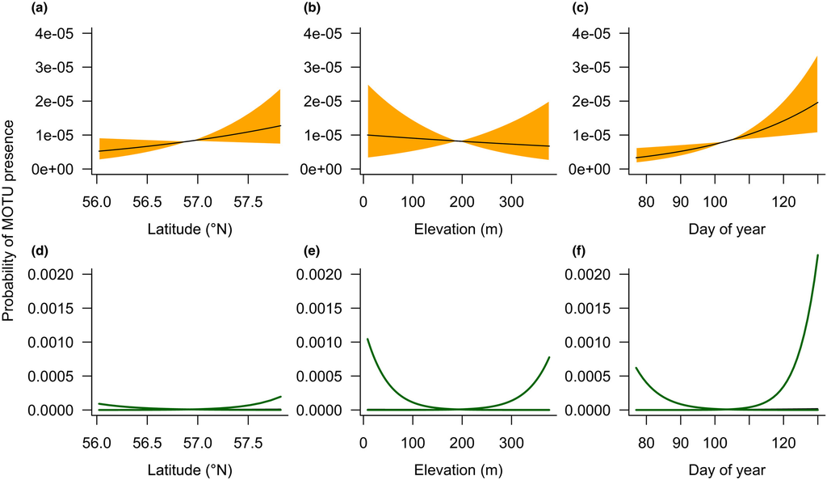

**Figure 2**

Dietary richness (a–c) and turnover (d–f) along latitudinal (a, d), elevational (b, e) and temporal (c, f) gradients. In a–c the solid black lines indicates the model prediction of dietary MOTU occurrence (related to richness), with the solid orange area illustrating the 95% credible intervals in the slope. In d–f the green lines correspond to the 95% upper and lower bounds of the estimated distribution of among‐MOTU slopes. The wider the difference between the upper and lower line in d–f the greater the turnover along the gradient. Predictions are made from the core model (Table S4a)

Table 2. Expectations for the MOTU richness of—and Jaccard indices between ‐samples of communities at (a) the same and (b) extreme points along latitude, elevation and day of year gradients. Expectations are calculated for a random sample, nestbox, day and site averaging over variation in other predictor variables (for further details see Appendix S1). Expectations were generated for 2014 and a single faecal sample

[output not shown]

- <sup>a</sup> The standardised Jaccard index is the ratio of the observed index to that expected if the same number of species were sampled at random from two communities (see Appendix S1). It will tend to be > 1 as common/widespread species will be over‐represented in both communities. The expectation for the Jaccard index and standardised index for two samples taken entirely at random from the transect is 0.01 (0.007–0.014) and 4.727 (3.891–5.732), respectively, and these values can be taken as a baseline that captures the effect of common/widespread species on measures of community similarity.

### 3.5 Dietary MOTU turnover

The probability of being present in a sample varied substantially across MOTUs (variance on probit scale = 0.574 [0.475–0.696], Table S5b in Appendix S1). From the interactions between MOTU identity and other terms we can gain insights into how the probability of sampling individual MOTUs changes over time and space, providing a measure of turnover and its significance. There was significant among MOTU variation in the slope of presence/absence on day of year, elevation and latitude (Table S5b in Appendix S1, Figure 2d–f), with MOTU turnover more pronounced over elevation and day of year. However, the predicted repeatabilities for MOTUs in faeces sampled at the same elevation (but at different sites) were rather low (Data; 0.002 [0.001–0.0030, Latent; 0.041 [0.028–0.059]). Due to the substantial between‐ faeces and between nest‐box variation in MOTU presence the repeatability for the site‐level probability of a MOTU at the same elevation was higher (Data; 0.066 [0.041–0.095], Latent; 0.148 [0.106–0.215]), but still modest. The effect of date was similarly low and even within nestboxes the repeatability of a MOTU in faeces from the same day was small (Data; 0.002 [0.001–0.004], Latent; 0.081 [0.057–0.114]). See Appendix S1 for further analysis of repeatabilities. As an alternative measure of how environmental variables affect community composition we calculated the expectation for the Jaccard index and standardised Jaccard index (Appendix S1) between two sites at (i) the mean and (ii) sampled extremes of latitude, elevation and day of year (Table 2). For all three environmental variables communities are less similar (lower Jaccard index) at the extremes than they are at the mean, but this effect is most pronounced for elevation and day of year.

We considered among‐MOTU variation in the relationship between the four continuous habitat variables and probability of occurrence in four additional models (Tables S5c–f). For three habitat metrics (total foliage, tree diversity and oak availability) among‐MOTU variation in habitat slopes was small and nonsignificant, implying no discernible MOTU turnover along these gradients. The slope of MOTU presence/absence on birch availability exhibited significant among‐MOTU variation, but turnover along this gradient is less than found for biogeographic and temporal gradients (Table S5f, Figure S4 in Appendix S1) indicating a weak relationship.

The variance in the MOTU identity by site effects was large (0.474 [0.394–0.551]), revealing that even after controlling for biogeographic trends in turnover gradients there is substantial MOTU turnover among sites (Table S5b). Indeed, the biogeographic and habitat variables in aggregate only explained a small fraction of the between site variance (Data; 0.101 [0.069–0.142], Latent; 0.236 [0.174–0.296], Appendix S1). The total within‐site (due to both biogeographic variation and random site variation) repeatability was small if assessed at the level of faeces (Data; 0.023 [0.016–0.029], Latent; 0.275 [0.242–0.306]) but larger if assessed at the level of nestboxes (Data; 0.270 [0.223–0.334], Latent; 0.568 [0.520–0.628]). This arises because of the considerable variance amongst faeces within a nestbox. The variance in MOTU identity by nestbox effects was comparable to the site effects (0.434 [0.376 –0.529]), but the within‐nestbox repeatability at a single site was small (Data; 0.016 [0.012–0.022], Latent; 0.275 [0.247–0.312]), again because of the large between‐ faeces variance. The within‐nestbox repeatability across sites (where site and nestbox effects contribute to the between group variance) was greater (Data; 0.069 [0.057–0.083], Latent; 0.474 [0.445–0.502]).

Interactions between MOTU and plate, plate‐row and plate‐column were also significant (Table S5b in Appendix S1), which may reflect within plate contamination. However, our placing of samples on the plate in the order in which samples were collected in the field (spatially and temporally structured) could also contribute to this signature if there is spatiotemporal structure in MOTU presence/absence that is not accounted for by the day of year:MOTU and site:MOTU terms.

### 3.6 Order level trends

Lepidoptera showed a significant increase in probability of occurrence with increasing latitude (b = 0.236 [0.044–0.430]) and elevation (b = 0.309 [0.073–0.583), Figure 3a,b, Table S6 in Appendix S1). Other than Lepidoptera, only Diptera also showed a significant increase with latitude (b = 0.252 [0.058–0.446]). Hymenoptera showed a significant increase in probability of occurrence with increasing elevation (b = 0.319 [0.061–0.557]), with positive trends also apparent for Diptera, Hemiptera and Coleoptera.

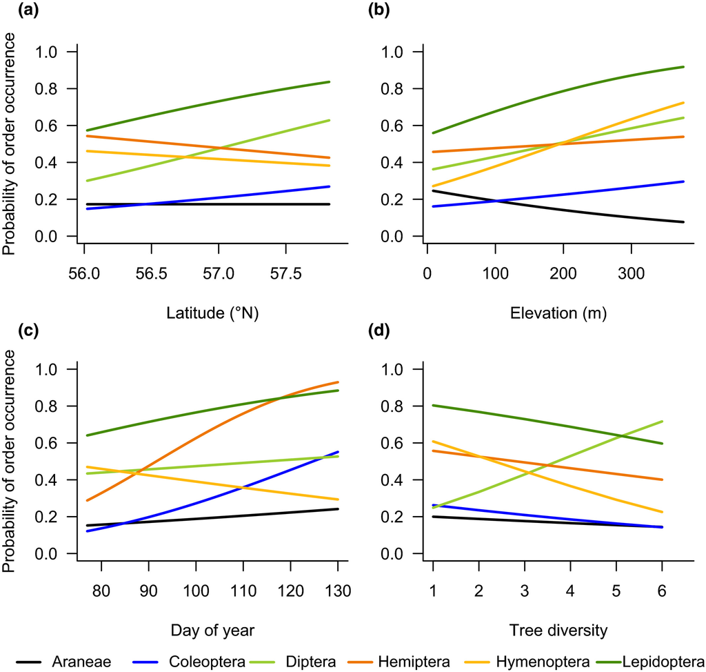

**Figure 3**

Model predictions for the occurence of six prey orders across (a) latitude, (b) elevation, (c) day of year, and (d) tree diversity. Predictions are made based on the intercept of the model reported in Table S5

## 4 DISCUSSION

We demonstrate that faecal metabarcoding can provide deep insights into the diet of a generalist woodland bird, and provide the first in‐depth analysis of the natural diet of a passerine bird prior to breeding. We show that across Scottish woodlands in early spring—when overall food availability is low—blue tits are able to locate and harvest over 400 prey taxa. Further, we show strong temporal patterns in the taxonomic richness and composition of the invertebrate prey items.

### 4.1 Diet composition

Our findings on blue tit diet composition broadly agree with previous work on this species (Betts, 1955; Gibb & Betts, 1963). As found by previous faecal metabarcoding studies on generalist insectivores (Clare, Fraser, Braid, Fenton, & Hebert, 2009; Jedlicka, Vo, & Almeida, 2016; Sedlock, Krüger, & Clare, 2014), we found most dietary taxa to be rare. The six most common orders were also detected using morphology‐based identification of gizzard contents by Betts (1955). For a fuller discussion of the commonest taxa see the extended discussion in Appendix S1.

One surprise in our data was the prevalence of winter moth early in the spring. The larvae of this species are one of the main foods provisioned to nestling tits (Betts, 1955; Perrins, 1991) and whilst they are the most common spring Lepidopteran larvae on our transect, their availability peaks in late May/early June (Shutt, Burgess, et al., 2019), and so we did not anticipate finding them in the diet in March/April. A post hoc analysis (GLMM with threshold response, site and nestbox effects as random and year effects as fixed) revealed that the probability of occurrence in a sample increases significantly in the days running up to the site‐average first egg laying date (b = 0.039, CI = 0.023–0.055), from around a 2% chance at 30 days prior to laying to 17% at the average site‐level blue tit first egg date. This increase in the incidence of winter moth in the diet most likely corresponds with a change in the availability of early instar larvae, rather than eggs, which would be available throughout the period (Waring & Townsend, 2017). This finding raises the possibility that tits might use early instars of winter moth and other foliar caterpillar larvae as a cue of when to breed.

### 4.2 Dietary richness and turnover

The biogeographic variables that we considered, latitude and elevation, had no significant effect upon dietary MOTU richness, but a significant effect upon dietary turnover. This reveals that whilst the total richness of prey eaten may not vary geographically (see also the very low site variance), the taxa comprising the diet vary along biogeographic clines (more so over elevation than latitude) and also from site to site, as revealed by the significant site by MOTU interaction component. These findings are consistent with those from faecal metabarcoding of insectivorous bats (Clare, Symondson, Broders, et al., 2014; Sedlock et al., 2014) and could indicate local dietary specialisation. However, we suspect that a more likely explanation for this apparent specialisation is that it arises from patterns in prey availability (Moran & Southwood, 1982) and that the birds are flexible in their prey.

The habitat indices that we consider were nonsignificant predictors of blue tit dietary richness, and MOTU turnover along such gradients was much weaker than estimated for the biogeographic and temporal variables. One potential explanation for our low estimate of turnover along such habitat gradients is that most invertebrate prey species may not be entirely restricted to a particular tree species. Alternatively, perhaps our “territory” based habitat metrics are inadequate measures of the availability of different tree species to each bird at this time. At face value our results are consistent with the greater importance of larger‐scale geographic clines (i.e., latitude, elevation) as determinants of prey presence/absence, presumably because they act as a proxy for other environmental variables that limit invertebrate distributions, such as temperature. However, substantial spatial turnover remained even after controlling for spatiotemporal gradients, which suggests that there are important drivers of prey turnover that we have overlooked.

### 4.3 Model based inference of richness and turnover

Describing and explaning temporal and geographical variation in components of diversity is a mainstay of community ecology (Dornelas et al., 2014; Li et al., 2018; Magurran, 2013). α‐diversity can be calculated for the sampled community scale (be that a location or point in time), which has made its statistical analysis relatively straightforward. In comparison, β‐diversity is often calculated as a pairwise similarity between communities (Koleff, Gaston, & Lennon, 2003), and where multiple communities are considered the nonindependence of comparisons presents a challenge to statistical inference (Baselga, 2010). In an important development Baeten et al. (2014) explained how a generalized linear model with taxon presence/absence as a binomial response could be used to estimate changes in richness and turnover between points and crucially determine statistical significance. Here, we have extended their framework to a generalized linear mixed model and we show that the interaction of taxon (MOTU) with categorical (random intercepts) and continuous (random slopes) variables estimates turnover between points (in space or time) and along gradients, respectively. We also show that it is possible to predict the Jaccard index (measure of β‐diversity) between a pair of communities sampled at points in space or time as a measure of effect size (Appendix S1). The principal benefits of this new model‐based approach over existing pairwise approaches are that: (a) it allows estimation of confidence intervals and *p*‐values for turnover and richness along gradients and among samples without such calculations being complicated by nonindependence; (b) hierarchical structure in the sampling can be included, and turnover can be assessed at each level explicitly taking into account heterogeneity in sampling effort at lower levels; (c) multiple covariates can be included; (d) inferences can be made including or excluding a control for taxon abundance, and (e) model based inference of repeatability is possible (see Appendix S1). The model coefficients can also be used to derive predictions of the total number of taxa in a community and the Jaccard index (or alternative β‐diversity metric) between communities. Our model is defined in the context of the probability of a taxon being present in a faecal sample, and as the number of samples (*n*) increases total taxon richness is predicted to increase monotonically (with a decelerating slope), such that when *n* = ∞, every taxon will be present. There are similarities between this curve and rarefaction curves that are often used to standardise for heterogeneity in sampling in ecology (Gotelli & Colwell, 2011), with both methods requiring inference of the probability of each taxon being in a sample. In addition, the Jaccard index will increase monotonically and with an accelerating function with increasing species richness (Appendix S1) and monotonically and with a decelerating function with sampling effort. Given that community level diversity metrics are highly sensitive to the choice of *n*, we suggest that when using our framework an *n* = 1 represents the most natural level at which to report community‐level metrics (see Appendix S1) and requires no extrapolation.

A limitation of our approach is that by imposing a parametric correlation structure on the data, that correlation structure is relatively simple and probably doesn't capture the full complexity of species associations. For example, if there was a patchily distributed species of herb on which three prey taxa were specialised on, then these three species would co‐occur with higher probability than our model would suggest. Rectifying these problem would require: (a) identifying the herb that generates these correlations, measuring its prevalence and incorporating that data into the model; (b) use more complex correlation structures to be modelled in situations where the number of taxa is large (Ovaskainen et al, 2017; Runcie & Mukherjee, 2013; Warton et al., 2015), or (c) develop sandwich type estimators (Huber, 1967; Zeger, Liang, & Albert, 1988) that would allow robust inferences to be made even when unmodelled correlations exist.

### 4.4 Methodological considerations

In this study we have demonstrated that faecal metabarcoding can provide a robust and powerful method for assessing passerine diet, allowing greater sample sizes and taxonomic resolution than direct assessment (Betts, 1955). Inclusion of positive and negative controls and repeat samples are part of the standard laboratory practice (Alberdi et al., 2018), although few previous metabarcoding studies have included any of these (but see De Barba et al., 2014; Jedlicka et al., 2016), and have proven invaluable in informing this work. Our protocol yielded fourteen MOTUs for the positive control taxon, suggesting that the 2% divergence rule of thumb used in early barcoding studies to group conspecific COI barcode sequences in Metazoa (Hebert, Cywinska, & Ball, 2003 and http://www.barcodinglife.com) is likely to produce spurious taxa, potentially misleading naïve analyses and underlining the necessity for subsequent quality control steps. Negative controls (extraction and PCR) allowed us to identify a case of systematic contamination and also informed our cutoff number of reads (but see Deagle et al., 2019 for a critique of thresholds). After strict removal of samples that appeared likely to have been affected by systematic contamination, some residual contamination on plates was evident and we were able to control for this to some degree by including row:MOTU, column:MOTU and plate:MOTU as random terms. We recommend that future studies adopt the plate:MOTU random term and randomise samples across plates, such that samples from a single year, site or time of year do not all appear on one plate. Although the maximum number of taxa in a sample was high (*n* = 20), PCR competition and the methodological maximum reads per metabarcoding plate presumably place a limit on detecting very rare dietary items. Reducing the number of target loci (three in this study, see methods) or level of multiplexing (i.e., the number of samples per sequencing run) could increase the reads available per locus per sample and increase detectability. However, reducing multiplexing may come at an increased financial cost for sequencing.

From our repeat samples we were able to estimate technical repeatability and several measures of biological repeatability (Appendix S1). Repeatability of MOTU presence/absence was rather low, consistent with low repeatability estimates found by another study that subsampled avian faecal samples (Jedlicka et al., 2016). An implication is that if the focus of an avian faecal metabarcoding study is on the detection of the presence/absence of a specific taxon, then multiple repeat DNA extractions, amplifications and metabarcoding runs are advisable. Homogenisation of faecal samples prior to DNA extraction may increase both the ability to detect a particular taxon and repeatability given the possible heterogeneity within single faeces.

In conclusion, using a metabarcoding approach, we reveal the diet of a generalist passerine at a finer resolution than any previous study and quantify dietary richness and turnover across space and time. At the scale of our study, blue tit dietary richness increases as spring progresses, but is unaffected by latitude, elevation and habitat, whilst dietary turnover is most pronounced over temporal (day of year) and elevational gradients.

## ACKNOWLEDGEMENTS

The authors thank Irene Benedicto Cabello and Ed Ivimey‐Cook for assistance in the field, Mark Blaxter for molecular advice, two anonymous reviewers for comments on the ms and Andrés Baselga for discussion of beta‐diversity. We are indebted to the landowners who allowed us access to their land. J.D.S. was funded by a NERC doctoral training studentship (NE/1338530), A.B.P. by a NERC Advanced fellowship (NE/I020598/1) and J.D.H. by a Royal Society URF.

## AUTHOR CONTRIBUTIONS

J.D.S., J.A.N., A.B.P., and J.D.H. were the main contributors to study conceptualization and methodology, with J.D.S., and A.B.P. responsible for fieldwork, J.A.N. responsible for designing and conducting the molecular work and J.D.H. designing the statistical methods, developing the theory and writing Appendix S1. J.D.S., and U.H.T. contributed to data curation. Statistical analysis was conducted by J.D.S., A.B.P., and J.D.H., A.B.P., was responsible for project administration and A.B.P., and J.D.H. for funding acquisition. J.D.S. wrote the original draft, and all authors contributed to further writing and editing.

## Citing Literature

[Volume29, Issue6](https://onlinelibrary.wiley.com/toc/1365294x/2020/29/6)

March 2020

Pages 1199-1213

### Metrics

- Citations: 3

### Details

  © 2020 John Wiley & Sons Ltd

[figure not shown]